# Guía básica de R

Bucles , if, Diagramas de barras y gráficos combinados

Óscar García Hernández

5 de noviembre de 2018

# Intro

Bueno chicos, repasando el capítulo anterior he de admitir que se me fue un poco la olla metiendo bucles. Por ello me gustaría profundizar en ello en este capítulo. Y lo vamos a hacer como llevamos tiempo haciendolo con los datos de los nuestros sensores y aplicando todas las cositas que ya hemos visto.

# Bucles

Ya sabemos que un bucle ejecuta acciones de manera cíclica. Ese ciclo está definido por un vector numérico que puede tomar los valores que nosotros queramos.  
Ese vector también puede tener el nombre que nosotros queramos

```r
for (variable in vector) {

}
```

El bucle se difine de la anterior manera. Mediante un for, entre paréntesis la variable y los valores que va a tomar (vector) y dentro de *{}* la acción que se ejecutará en el for.  
Para ver el comportamiento de un bucle puede ser útil el comando **print()**. Lo único que hace es sacar por consola lo que pongamos dentro del paréntesis.

```r
print(1)
```

```
## [1] 1
```

```r
print("Perro")
```

```
## [1] "Perro"
```

Esto lo podemos usar para ver lo que ocurre dentro de un bucle

```r
for (numero in 1:7) {

  print(numero)
}
```

```
## [1] 1
## [1] 2
## [1] 3
## [1] 4
## [1] 5
## [1] 6
## [1] 7
```

```r
for (numero in seq(5,6,by = 0.2)) {

  print(numero)
}
```

```
## [1] 5
## [1] 5.2
## [1] 5.4
## [1] 5.6
## [1] 5.8
## [1] 6
```

Esto que acabo de hacer es una chorrada pero nos puede valer para entender que una variable ejecutada en un bucle puede tomar cualquier valor.  
Otra de las cosas que se suele hacer a la hora de ejectuar bucles es que la variable del bucle llame a un vector que se encuentra fuera del mismo.

```r
numero <- seq(5,6,by = 0.2)

for (i in 1:6) {

  print(numero[i])
}
```

```
## [1] 5
## [1] 5.2
## [1] 5.4
## [1] 5.6
## [1] 5.8
## [1] 6
```

Se suele utilizar este método por sencillez, ya que incluso se puede configurar la variable del bucle para que ejecute todos los elementos del vector “numero” sin saber su longitud, empleando *length()*. Esto se utiliza mucho por comodidad.

```r
numero <- seq(5,6,by = 0.2)

for (i in 1:length(numero)) {

  print(numero[i])
}
```

```
## [1] 5
## [1] 5.2
## [1] 5.4
## [1] 5.6
## [1] 5.8
## [1] 6
```

# Bucles y datos

A la hora de tratar datos ya vimos que los bucles se pueden utilizar para clasificar los datos, analizarlos, modificar tablas, graficar resultados etc. Es decir, *VALEN PARA TODO* Y POR ESO MISMO DEBEN SER NUESTROS AMIGOS.  
Pasamos ahora a importar los datos de los sensores como ya sabemos.

```r
library(rlist)
library(here)

Datos<- list.load(here::here("data/Datos_anemometros.rdata"))
```

Con intencion de ver un poco como se organizan todos los datos, vamos a tratar con los datos del pluviómetro.  
Ya hemos visto que muchas veces los datos vienen en formatos de mierda y hay que modificarlos, no voy ni a explicarlo de nuevo. Pego código y listo.

```r
pluv_5 <- Datos$pluv5

library(lubridate)
pluv_5$date_string_hour<- dmy_hms(as.character(pluv_5$date_string_hour))
pluv_5$`rain (mm)`<- as.numeric(as.character(pluv_5$`rain (mm)`))
```

Comentar a cerca del pluviómetro que tiene una manera de registrar datos de manera particular. Solamente existen datos de cuando llueve. Por lo tanto tendremos muchos huecos en el *dataset*. Además, hay que darse cuenta de que la lluvia se expresa en milimetros que es lo mismo que litros por metro cuadrado y que se expresa como lluvia acumulada. Se me ocurre que podemos modificar esta información y representar la lluvia como litros/metro cuadrado por mes.  
Para esto vamos a usar la potencia del paquete lubridate y un bucle.  
Primero vemos cuantos meses hay en la tabla. Usamos unique() usamos month() y algunos parámetros del comando month, para obtener los meses en formato palabra. Esto es una pijada, pero me sirve para explicaros que **aunque conozcamos un comando**, por ejemplo, el comando month(), **es interesante ver la ayuda** del comando **para ver cuales son todas sus posibilidades, es probable que nos sorprenda.** La gra mayoria de comandos que usamos tienen parámetros modificables que no conocemos y que es probable que simplifiquen nuestro código.

```r
unique(month(pluv_5$date_string_hour,label=TRUE,abbr = FALSE))
```

```
## [1] octubre    septiembre agosto     julio      junio
## 12 Levels: enero < febrero < marzo < abril < mayo < junio < ... < diciembre
```

Vemos que tenemos datos desde junio a octubre.

```r
lluvia_mensual <- vector()
vector_meses<- unique(month(pluv_5$date_string_hour))

for (i in 1:length(vector_meses)) {

  #creo un vector con la lluvia acumulada del mes
  lluvia_mes <- pluv_5$`rain (mm)`[month(pluv_5$date_string_hour) == vector_meses[i]]


  #Máximo menos mínimo para obtener la lluvia producida en ese mes
  lluvia_mensual[i]<- max(lluvia_mes)-min(lluvia_mes)
}
```

Es importante saber en qué orden se ejecuta el orden para no confundir datos. En nuestro caso se ejecuta desde octubre hasta junio, es decir, el primer dato de lluvia mensual es la lluvia de octubre.  
Este tipo de datos se pueden representar un diagrama de barras, queda bien.

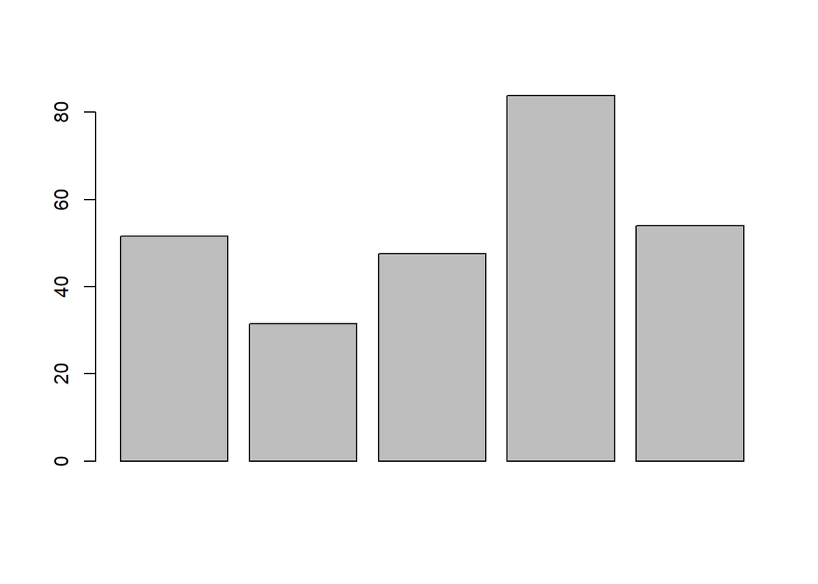

```r
barplot(lluvia_mensual)
```

SE puede maquillar poniendo nombres a las columnas, títulos y demás. Los nombres de las columnas los podemos emplear usando los parámetros del comando month()[lubridate]

```r
nombres <- as.character(
    unique(
        month(pluv_5$date_string_hour,
              label=TRUE,
              abbr = FALSE)))
```

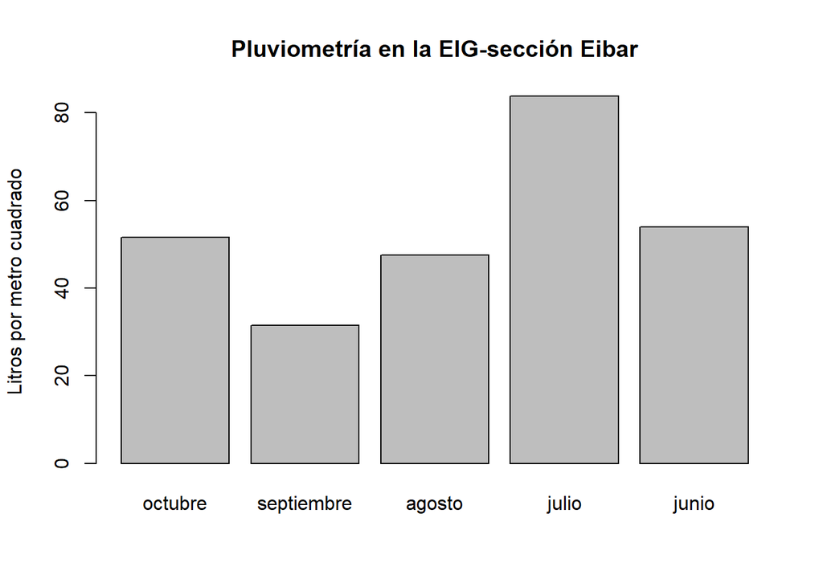

```r
barplot(lluvia_mensual, names.arg = nombres,
        ylab = "Litros por metro cuadrado",
        main = "Pluviometría en la EIG-sección Eibar")
```

Bueno… Siguiendo con los bucles, vamos a complicar la cosa, vamos a hacer lo mismo, pero ahora, haciendo el registro de la lluvia por días. Lo cual se puede hacer por varios métodos pero nosotros vamos a emplear un bucle doble, es decir, un bucle dentro de otro bucle.

```r
lista_lluvia<- list()
vector_meses<- unique(month(pluv_5$date_string_hour))

for (i in 1:length(vector_meses)) {

  #Corto los datos del mes
  Datos_mes <- pluv_5[month(pluv_5$date_string_hour) == vector_meses[i],]

  #Miro cuantos días aparecen en la tabla (días de lluvia)
  vector_dias<- unique(mday(Datos_mes$date_string_hour))

  #Comando nuevo, miro cuantos días tienen el mes a analizar
  dias_mes <- unique(days_in_month(Datos_mes$date_string_hour))

  # Vector pa guardar lluvia diaria
   lluvia_diaria <- vector()
  for (j in 1:dias_mes) {

    if(sum(j==vector_dias ) != 0){

      Datos_dia <- Datos_mes$`rain (mm)`[
        mday(Datos_mes$date_string_hour)==j]

      lluvia_diaria[j] <- max(Datos_dia) - min(Datos_dia)

    }else{lluvia_diaria[j] <- 0}

  }

   lista_lluvia[[i]] <- lluvia_diaria

}


#Nombramos los elementos de la lista
names(lista_lluvia)<- vector_meses
```

Parece que hay muchas cosas raras en este bucle pero trankilos, QUE NO CUANDA EL PÁNICO. Hay un bucle doble para: el primer bucle corta los datos por meses y el segundo bucle, una vez el primer bucle ha cortado los datos del mes, los corta por días.

# if

He añadido un **if**. Ahora explicaré para qué. Ya vimos que los dias que no llueven no se ven representados en la tabla. Yo lo que he hecho es crear un bucle que añada un 0 el día que no llueva. ¿Cómo?, implementando un if.

```r
if(condicion = TRUE o FALSE){

  accion1


}else{

  accion2

  }
```

Un if funciona con una condición lógica, es decir, entre los parentesis tenemos que introducir un valor que sea **TRUE o FALSE**. Si la condición es TRUE se realiza la acción1 que se encuentra entre los corchetes del if. si la condición es FALSE se realiza la accion2 que se encuentra dentro del corchete del *else*. **LO NORMAL ES SIEMPRE USAR EL IF JUNTO CON EL ELSE**.  
De hecho R, nos ofrece un comando que se utiliza como *ifelse()*. Y se usa como:

```r
ifelse(condicion,accion1[TRUE], accion2[FALSE])
```

Tengo que reconocer que la condición que he usado para el bucle de la lluvia diaria es un poco rebuscada. A continuación explico la lógica.

```r
if(sum(j==vector_dias ) != 0){
  .
  .
  .
}
```

- j: es la variable del bucle que hace un barrido desde 1 hasta 31. Todos los dias del mes.
- vector_dias: contiene la información de los días del mes que ha llovido.  
  Lo que hace esa condición es verificar si ha llovido ese día. **YO PUEDO SUMAR VECTORES LÓGICOS, empleando sum()**. Esto lo usamos para verificar cuantas veces se cumple una condición. Porque el valor **TRUE=1 y el valor FALSE=0**

# Gráficos combinados

Aprovechando que tenemos una lista de 5 elementos, voy a aprovechar a explicar rápidamente que en R se pueden representar gráficos diferentes en la misma ventana.  
Se puede hacer de varias maneras, por ejemplo:

```r
par(mfrow=c("filas","columnas"))
```

Este comando divide la ventana de gráficos en columnas y filas. y cada emplezamiento de la ventana se dedicará a una gráfica.  
A continuación realizaremos las gráficas empleando un bucle, como no¡

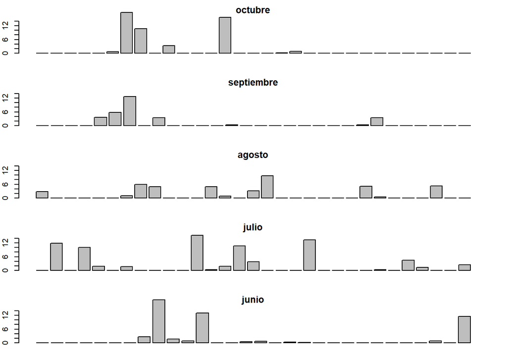

```r
par(mfrow=c(5,1))

#Obtengo los nombres de los meses para incluirlos en las gráficas
nombres_meses <- as.character(
  month(
    as.numeric(names(lista_lluvia)),
    label=TRUE,
    abbr = FALSE))


for (i in 1:length(lista_lluvia)) {
  par(mar = rep(2, 4))

  barplot(lista_lluvia[[i]], main = nombres_meses[i], ylim = c(0,15))
}
```

Un detalle, que me gustaría comentar es que a la de representar gráficos “juntos” es importe que sean fácilmente complarables, para ello es interesante que los ejes, tengan el mismo tamaño, para ello se utiliza **ylim()**. Se fijan los tamaños de del eje y para que sean en todos igual.

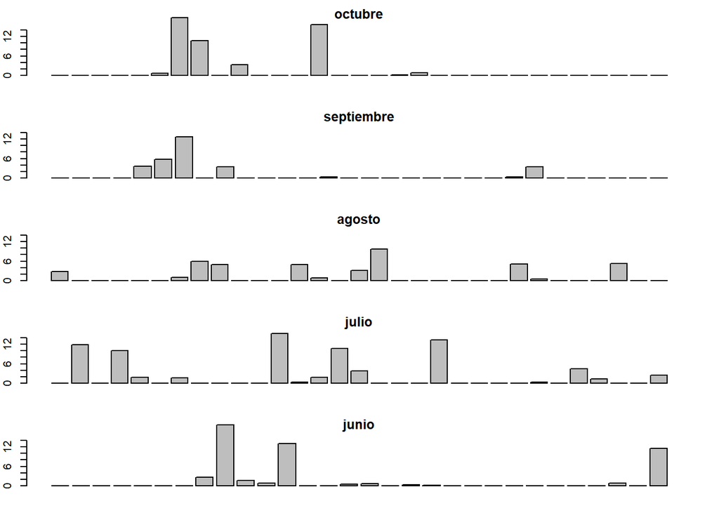

```r
par(mfrow=c(5,1))

#Obtengo los nombres de los meses para incluirlos en las gráficas
nombres_meses <- as.character(
  month(
    as.numeric(names(lista_lluvia)),
    label=TRUE,
    abbr = FALSE))


for (i in 1:length(lista_lluvia)) {
  par(mar = rep(2, 4))

  barplot(lista_lluvia[[i]], main = nombres_meses[i], ylim = c(0,15))
}
```

Tambien existe el comando **layout()** para separar la ventana de gráficos. Ya lo utilizaremos, o no¡¡, pero que sepan que existen más maneras, esta es la forma más básica y por ello es interesante usarla. por simplicidad.